# Practical 1 — Airline Passengers

## 4. Estimating a linear trend.

In the code above we have defined two objects, t and x (time and airline passengers respectively). We will try, in the next block, to obtain the best linear approximation of our data:

```r
t3<-1:144 # create a simple time index:
line=lm(y~t3) # fits a linear regression model (fit the best straight line through the data)
summary(line)
```

```
##
## Call:
## lm(formula = y ~ t3)
##
## Residuals:
##      Min       1Q   Median       3Q      Max
## -0.30858 -0.10388 -0.01796  0.09738  0.29538
##
## Coefficients:
##              Estimate Std. Error t value Pr(>|t|)
## (Intercept) 4.8136683  0.0232940  206.65   <2e-16 ***
## t3          0.0100484  0.0002787   36.05   <2e-16 ***
## ---
## Signif. codes:  0 '***' 0.001 '**' 0.01 '*' 0.05 '.' 0.1 ' ' 1
##
## Residual standard error: 0.139 on 142 degrees of freedom
## Multiple R-squared:  0.9015, Adjusted R-squared:  0.9008
## F-statistic:  1300 on 1 and 142 DF,  p-value: < 2.2e-16
```

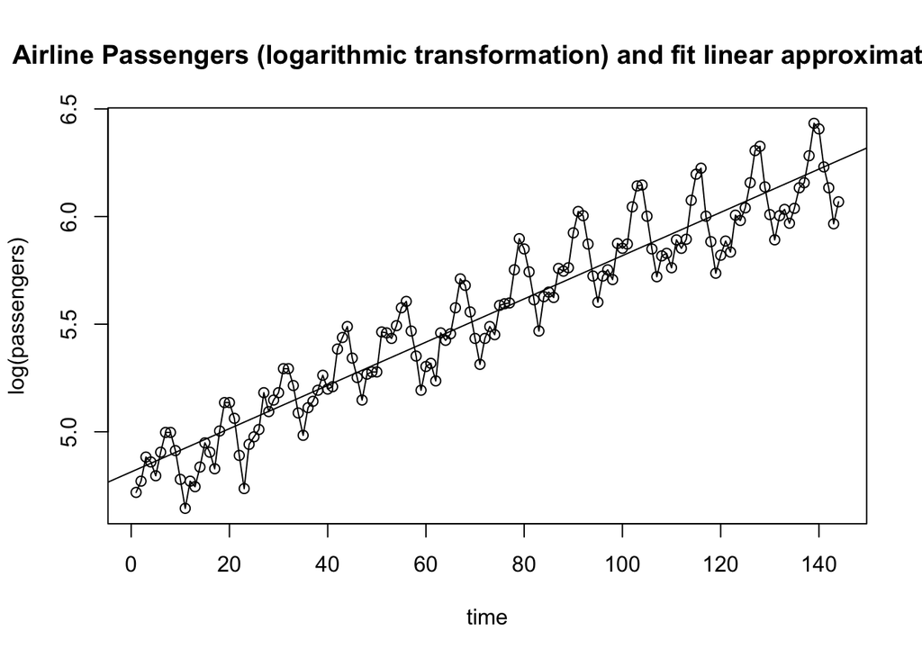

```r
plot(t3, y, main="Airline Passengers (logarithmic transformation) and fit linear approximation", type="o", xlab="time", ylab="log(passengers)");
abline(line) #Adds the fitted regression line on top of the plot
```

```r
#To extract the trend to the logarithmic data we can do:
y<-log(x)
lm(y~t3)
```

```
##
## Call:
## lm(formula = y ~ t3)
##
## Coefficients:
## (Intercept)           t3
##     4.81367      0.01005
```

```r
trend<-0.01005*t3+4.81367
trend
```

```
##   [1] 4.82372 4.83377 4.84382 4.85387 4.86392 4.87397 4.88402 4.89407 4.90412
##  [10] 4.91417 4.92422 4.93427 4.94432 4.95437 4.96442 4.97447 4.98452 4.99457
##  [19] 5.00462 5.01467 5.02472 5.03477 5.04482 5.05487 5.06492 5.07497 5.08502
##  [28] 5.09507 5.10512 5.11517 5.12522 5.13527 5.14532 5.15537 5.16542 5.17547
##  [37] 5.18552 5.19557 5.20562 5.21567 5.22572 5.23577 5.24582 5.25587 5.26592
##  [46] 5.27597 5.28602 5.29607 5.30612 5.31617 5.32622 5.33627 5.34632 5.35637
##  [55] 5.36642 5.37647 5.38652 5.39657 5.40662 5.41667 5.42672 5.43677 5.44682
##  [64] 5.45687 5.46692 5.47697 5.48702 5.49707 5.50712 5.51717 5.52722 5.53727
##  [73] 5.54732 5.55737 5.56742 5.57747 5.58752 5.59757 5.60762 5.61767 5.62772
##  [82] 5.63777 5.64782 5.65787 5.66792 5.67797 5.68802 5.69807 5.70812 5.71817
##  [91] 5.72822 5.73827 5.74832 5.75837 5.76842 5.77847 5.78852 5.79857 5.80862
## [100] 5.81867 5.82872 5.83877 5.84882 5.85887 5.86892 5.87897 5.88902 5.89907
## [109] 5.90912 5.91917 5.92922 5.93927 5.94932 5.95937 5.96942 5.97947 5.98952
## [118] 5.99957 6.00962 6.01967 6.02972 6.03977 6.04982 6.05987 6.06992 6.07997
## [127] 6.09002 6.10007 6.11012 6.12017 6.13022 6.14027 6.15032 6.16037 6.17042
## [136] 6.18047 6.19052 6.20057 6.21062 6.22067 6.23072 6.24077 6.25082 6.26087
```

```r
z<-y-trend #z=residuals of the time series after log transforming and extracting the linear trend.
z
```

```
##   [1] -0.1052211287 -0.0630853755  0.0389819226  0.0059424044 -0.0681294544
##   [6]  0.0313047784  0.1131922738  0.1031422738  0.0085348857 -0.1350465069
##  [11] -0.2798291009 -0.1635853755 -0.1993878716 -0.1180880930 -0.0156601096
##  [16] -0.0691952216 -0.1562062627  0.0093763059  0.1311784371  0.1211284371
##  [21]  0.0378750330 -0.1444208718 -0.3086215516 -0.1132275774 -0.0881862576
##  [26] -0.0643347059  0.0967635503 -0.0013197992  0.0423744768  0.0666135503
##  [31]  0.1680848247  0.1580348247  0.0696157576 -0.0677736648 -0.1818133783
##  [36] -0.0634822116 -0.0438564435 -0.0026131491  0.0570701889 -0.0171729687
##  [41] -0.0162338472  0.1487250628  0.1922593089  0.2330677262  0.0764142520
##  [46] -0.0236965720 -0.1385255232 -0.0282118409 -0.0280053408 -0.0380553408
##  [51]  0.1376118050  0.1233155141  0.0874020036  0.1366914433  0.2095291031
##  [56]  0.2293320663  0.0815401411 -0.0447118665 -0.2136631491 -0.1133650919
##  [61] -0.1086000062 -0.2003280372  0.0127655141 -0.0319199825 -0.0115988846
##  [66]  0.0989791031  0.2234070174  0.1831026090  0.0497080617 -0.0834479964
##  [71] -0.2140140210 -0.1035479964 -0.0583822738 -0.1063315464  0.0198286584
##  [76]  0.0172413796  0.0109019590  0.1550026388  0.2895338676  0.2316547799
##  [81]  0.1152831878 -0.0246418936 -0.1797598589 -0.0302488863 -0.0189457618
##  [86] -0.0539524938  0.0708817739  0.0481331905  0.0539313828  0.2060857974
##  [91]  0.2952275930  0.2656170671  0.1237977895 -0.0347848980 -0.1663011791
##  [96] -0.0548848980 -0.0359473612 -0.0914597353  0.0663107309  0.0335324798
## [101]  0.0433977895  0.2062353140  0.2932174056  0.2874592577  0.1324948780
## [106] -0.0296452201 -0.1687082234 -0.0819588400 -0.0801743824 -0.1571186172
## [111] -0.0375757882 -0.0870675202 -0.0549171657  0.1159760311  0.2270241278
## [116]  0.2450884293  0.0118948780 -0.1162476115 -0.2730477025 -0.1995870696
## [121] -0.1436159685 -0.2049592629 -0.0434668404 -0.0784557887 -0.0296652887
## [126]  0.0770089856  0.2162552869  0.2260794732  0.0276070541 -0.1113568146
## [131] -0.2385757882 -0.1363829329 -0.1172337782 -0.1916624400 -0.1325490801
## [136] -0.0470719570 -0.0335410144  0.0816967469  0.2223200927  0.1862099861
## [141] -0.0002385524 -0.1073719570 -0.2846732609 -0.1924444118
```

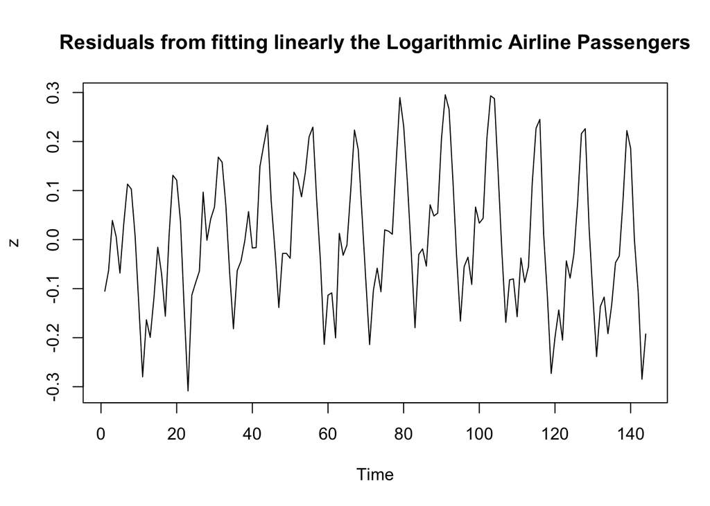

```r
plot.ts(z, main="Residuals from fitting linearly the Logarithmic Airline Passengers")
```

In plot **“Airline Passengers (logarithmic transformation) and fit linear approximation”** we represented the logarithmic time series with the line that best fits it.

Then, we represented the line as: *trend = 0.01005*t3 + 4.81367* and computed the residuals:

- **At each time point:** *residual = actual value - predicted trend value*

Eventually we plot the residuals: this allows us to observe the following aspects, which are otherwise not explained by the trend: seasonality, short-term fluctuations, noise.

## 5. Estimating the seasonal component

```r
# To eliminate seasonality of z we can do:
dim(z)<-c(12,12)
z
```

```
##               [,1]         [,2]         [,3]         [,4]        [,5]
##  [1,] -0.105221129 -0.199387872 -0.088186258 -0.043856443 -0.02800534
##  [2,] -0.063085376 -0.118088093 -0.064334706 -0.002613149 -0.03805534
##  [3,]  0.038981923 -0.015660110  0.096763550  0.057070189  0.13761181
##  [4,]  0.005942404 -0.069195222 -0.001319799 -0.017172969  0.12331551
##  [5,] -0.068129454 -0.156206263  0.042374477 -0.016233847  0.08740200
##  [6,]  0.031304778  0.009376306  0.066613550  0.148725063  0.13669144
##  [7,]  0.113192274  0.131178437  0.168084825  0.192259309  0.20952910
##  [8,]  0.103142274  0.121128437  0.158034825  0.233067726  0.22933207
##  [9,]  0.008534886  0.037875033  0.069615758  0.076414252  0.08154014
## [10,] -0.135046507 -0.144420872 -0.067773665 -0.023696572 -0.04471187
## [11,] -0.279829101 -0.308621552 -0.181813378 -0.138525523 -0.21366315
## [12,] -0.163585376 -0.113227577 -0.063482212 -0.028211841 -0.11336509
##              [,6]        [,7]        [,8]        [,9]       [,10]       [,11]
##  [1,] -0.10860001 -0.05838227 -0.01894576 -0.03594736 -0.08017438 -0.14361597
```

[output cut: 24 more lines]

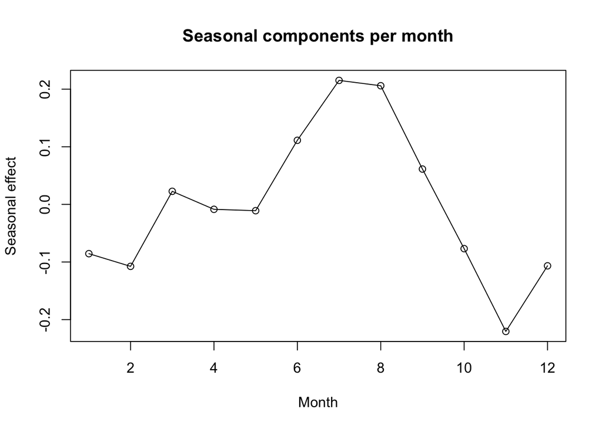

```r
#We have converted the series in a matrix where rows are data of the same month.
#Now we compute monthly row means, the global mean and the seasonal component.
e<-apply(z,1,mean)
ee<-mean(e)
s<-e-ee
plot(s,main = "Seasonal components per month", ylab="Seasonal effect", xlab="Month", type="o")
```

```r
#We have now captured the seasonal component. Now we do:
est<-array(s,144)
est
```

```
##   [1] -0.085510673 -0.107546692  0.022699235 -0.008550814 -0.010904651
##   [6]  0.111260355  0.215221486  0.205945452  0.061329655 -0.076809781
##  [11] -0.220508687 -0.106624886 -0.085510673 -0.107546692  0.022699235
##  [16] -0.008550814 -0.010904651  0.111260355  0.215221486  0.205945452
##  [21]  0.061329655 -0.076809781 -0.220508687 -0.106624886 -0.085510673
##  [26] -0.107546692  0.022699235 -0.008550814 -0.010904651  0.111260355
##  [31]  0.215221486  0.205945452  0.061329655 -0.076809781 -0.220508687
##  [36] -0.106624886 -0.085510673 -0.107546692  0.022699235 -0.008550814
##  [41] -0.010904651  0.111260355  0.215221486  0.205945452  0.061329655
##  [46] -0.076809781 -0.220508687 -0.106624886 -0.085510673 -0.107546692
##  [51]  0.022699235 -0.008550814 -0.010904651  0.111260355  0.215221486
##  [56]  0.205945452  0.061329655 -0.076809781 -0.220508687 -0.106624886
##  [61] -0.085510673 -0.107546692  0.022699235 -0.008550814 -0.010904651
##  [66]  0.111260355  0.215221486  0.205945452  0.061329655 -0.076809781
##  [71] -0.220508687 -0.106624886 -0.085510673 -0.107546692  0.022699235
##  [76] -0.008550814 -0.010904651  0.111260355  0.215221486  0.205945452
##  [81]  0.061329655 -0.076809781 -0.220508687 -0.106624886 -0.085510673
##  [86] -0.107546692  0.022699235 -0.008550814 -0.010904651  0.111260355
##  [91]  0.215221486  0.205945452  0.061329655 -0.076809781 -0.220508687
##  [96] -0.106624886 -0.085510673 -0.107546692  0.022699235 -0.008550814
## [101] -0.010904651  0.111260355  0.215221486  0.205945452  0.061329655
## [106] -0.076809781 -0.220508687 -0.106624886 -0.085510673 -0.107546692
## [111]  0.022699235 -0.008550814 -0.010904651  0.111260355  0.215221486
## [116]  0.205945452  0.061329655 -0.076809781 -0.220508687 -0.106624886
## [121] -0.085510673 -0.107546692  0.022699235 -0.008550814 -0.010904651
## [126]  0.111260355  0.215221486  0.205945452  0.061329655 -0.076809781
## [131] -0.220508687 -0.106624886 -0.085510673 -0.107546692  0.022699235
## [136] -0.008550814 -0.010904651  0.111260355  0.215221486  0.205945452
## [141]  0.061329655 -0.076809781 -0.220508687 -0.106624886
```

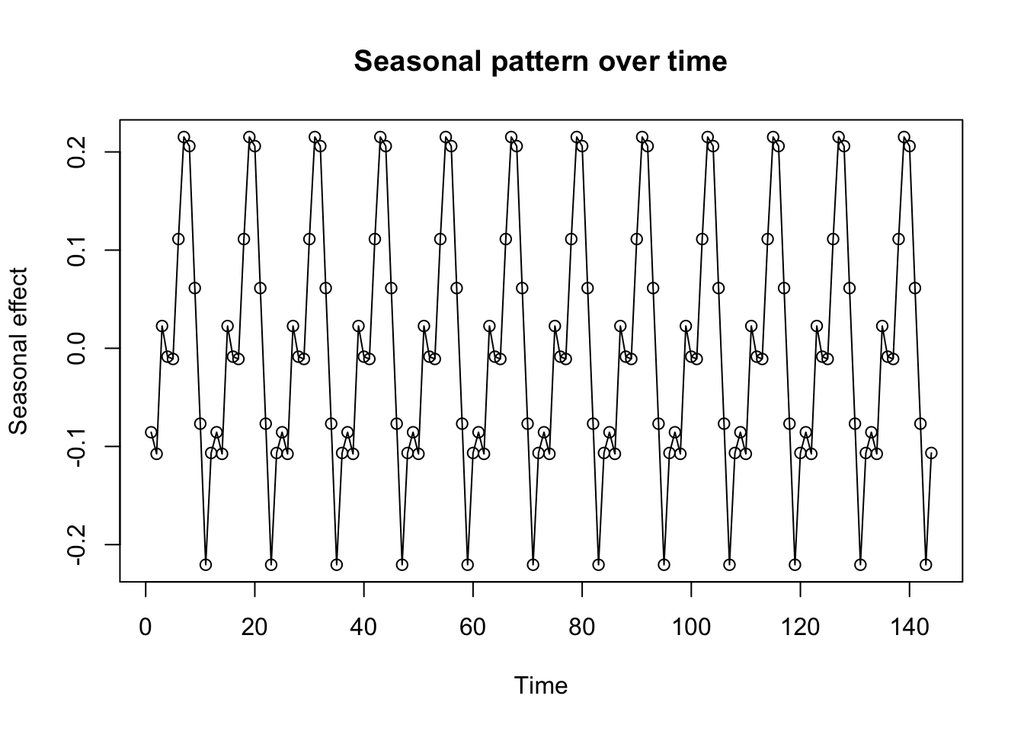

```r
plot(est,main = "Seasonal pattern over time", ylab = "Seasonal effect", xlab = "Time",type="o")
```

```r
dim(z)<-144
u<-z-est
u
```

```
##   [1] -0.0197104556  0.0444613161  0.0162826873  0.0144932187 -0.0572248037
##   [6] -0.0799555762 -0.1020292126 -0.1028031786 -0.0527947696 -0.0582367256
##  [11] -0.0593204142 -0.0569604893 -0.1138771986 -0.0105414014 -0.0383593449
##  [16] -0.0606444072 -0.1453016120 -0.1018840487 -0.0840430493 -0.0848170153
##  [21] -0.0234546223 -0.0676110905 -0.0881128650 -0.0066026911 -0.0026755845
##  [26]  0.0432119857  0.0740643150  0.0072310151  0.0532791275 -0.0446468043
##  [31] -0.0471366616 -0.0479106276  0.0082861023  0.0090361165  0.0386953083
##  [36]  0.0431426746  0.0416542296  0.1049335425  0.0343709536 -0.0086221544
##  [41] -0.0053291964  0.0374647082 -0.0229621774  0.0271222738  0.0150845967
##  [46]  0.0531132093  0.0819831634  0.0784130453  0.0575053323  0.0694913509
##  [51]  0.1149125697  0.1318663285  0.0983066543  0.0254310887 -0.0056923832
##  [56]  0.0233866140  0.0202104858  0.0320979148  0.0068455375 -0.0067402057
##  [61] -0.0230893331 -0.0927813455 -0.0099337211 -0.0233691682 -0.0006942339
##  [66] -0.0122812515  0.0081855310 -0.0228428433 -0.0116215936 -0.0066382152
##  [71]  0.0064946657  0.0030768898  0.0271283992  0.0012151452 -0.0028705769
##  [76]  0.0257921939  0.0218066097  0.0437422842  0.0743123813  0.0257093276
##  [81]  0.0539535325  0.0521678877  0.0407488277  0.0763759999  0.0665649112
##  [86]  0.0535941978  0.0481825386  0.0566840049  0.0648360335  0.0948254428
##  [91]  0.0800061066  0.0596716148  0.0624681342  0.0420248832  0.0542075075
##  [96]  0.0517399882  0.0495633119  0.0160869564  0.0436114956  0.0420832941
## [101]  0.0543024402  0.0949749594  0.0779959192  0.0815138053  0.0711652227
## [106]  0.0471645612  0.0518004632  0.0246660462  0.0053362907 -0.0495719256
## [111] -0.0602750235 -0.0785167059 -0.0440125150  0.0047156765  0.0118026414
## [116]  0.0391429770 -0.0494347773 -0.0394378302 -0.0525390159 -0.0929621834
## [121] -0.0581052955 -0.0974125713 -0.0661660757 -0.0699049744 -0.0187606380
## [126] -0.0342513690  0.0010338006  0.0201340208 -0.0337226012 -0.0345470333
## [131] -0.0180671016 -0.0297580466 -0.0317231051 -0.0841157484 -0.1552483154
## [136] -0.0385211427 -0.0226363637 -0.0295636077  0.0070986064 -0.0197354663
## [141] -0.0615682077 -0.0305621757 -0.0641645743 -0.0858195255
```

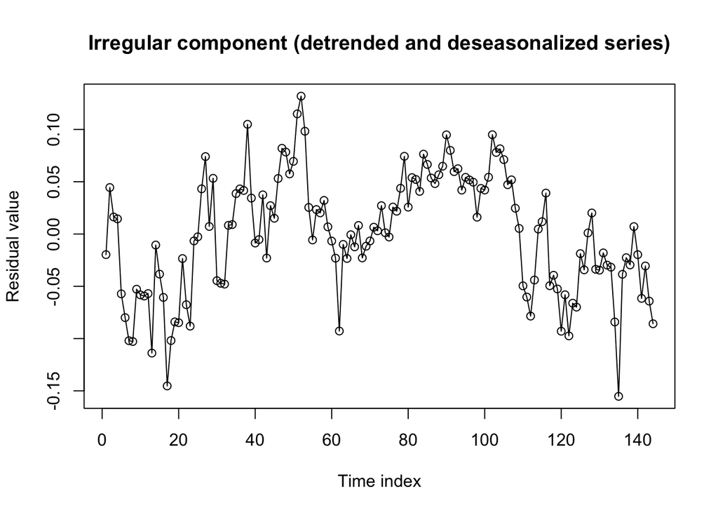

```r
plot(u, main="Irregular component (detrended and deseasonalized series)", xlab="Time index", ylab="Residual value", type="o")
```

The plots above show: 1. Seasonal component over 12 months 2. Seasonal component over time (144 time units) 3. Irregular component (de-trended and de-seasonalized series)

The plots 1 and 2 show values around 0, specifically between approximately -0.2 and 0.2. This is due to the fact that the **seasonal component “s”** has been centered. In fact, it is obtained by subtracting the global mean from each monthly average: **s = e-ee**.

Then, the **vector est** is obtained by repeating the *seasonal component “s”* over the entire time period (144 time units) so that it matches the length of the series. As a consequence, also the plot of est (2nd plot) is centered around 0, with values between approximately -0.2 and 0.2.

## 6. Filtering

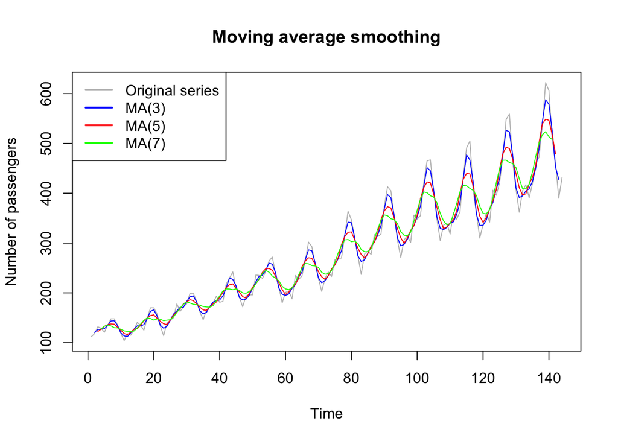

```r
#Given x, the following instruction applies a moving average of order q=1 to the series:
v3<-filter(x, sides=2,rep(1,3)/3) #It replaces each observation with the average of its neighbors. So noise is reduced → smoother curve.

v5<-filter(x, sides=2, rep(1,5)/5)
v7<-filter(x, sides=2, rep(1,7)/7)

plot(x, type="l", main = "Moving average smoothing", xlab="Time", ylab="Number of passengers", col="grey")
lines(v3, col="blue")
lines(v5, col="red")
lines(v7, col="green")

legend("topleft",
       legend = c("Original series",
                  "MA(3)",
                  "MA(5)",
                  "MA(7)"),
       col = c("grey","blue","red","green"),
       lty = 1,
       lwd = 2)
```

What we represent in the plot:

- MA(3) → moving average with window size 3
- MA(5) → window size 5
- MA(7) → window size 7

**Observations:**

The moving averages make the time series smoother, by reducing the fluctuations. In fact, the moving average replaces each observation with the average of its neighbors (3, 5 or 7 neighbors depending on the size of the window).

In this way the noise is “averaged out” for adjacent time points, and hence the filtered time series is smoother, with less noise and it highlights the underlying trend of the series more clearly.

On the other side, larger windows also mean compromising with less visibility into short-term changes.

## 7. Differentiation

```r
y<-log(x)
dy<-diff(y) #first order difference
dy
```

```
##   [1]  0.052185753  0.112117298 -0.022989518 -0.064021859  0.109484233
##   [6]  0.091937495  0.000000000 -0.084557388 -0.133531393 -0.134732594
##  [11]  0.126293725 -0.025752496  0.091349779  0.112477983 -0.043485112
##  [16] -0.076961041  0.175632569  0.131852131  0.000000000 -0.073203404
##  [21] -0.172245905 -0.154150680  0.205443974  0.035091320  0.033901552
##  [26]  0.171148256 -0.088033349  0.053744276  0.034289073  0.111521274
##  [31]  0.000000000 -0.078369067 -0.127339422 -0.103989714  0.128381167
##  [36]  0.029675768  0.051293294  0.069733338 -0.064193158  0.010989122
##  [41]  0.175008910  0.053584246  0.050858417 -0.146603474 -0.090060824
##  [46] -0.104778951  0.120363682  0.010256500  0.000000000  0.185717146
##  [51] -0.004246291 -0.025863511  0.059339440  0.082887660  0.029852963
##  [56] -0.137741925 -0.116202008 -0.158901283  0.110348057  0.014815086
##  [61] -0.081678031  0.223143551 -0.034635497  0.030371098  0.120627988
##  [66]  0.134477914 -0.030254408 -0.123344547 -0.123106058 -0.120516025
##  [71]  0.120516025  0.055215723 -0.037899273  0.136210205  0.007462721
##  [76]  0.003710579  0.154150680  0.144581229 -0.047829088 -0.106321592
##  [81] -0.129875081 -0.145067965  0.159560973  0.021353124 -0.024956732
##  [86]  0.134884268 -0.012698583  0.015848192  0.162204415  0.099191796
##  [91] -0.019560526 -0.131769278 -0.148532688 -0.121466281  0.121466281
##  [96]  0.028987537 -0.045462374  0.167820466 -0.022728251  0.019915310
## [101]  0.172887525  0.097032092  0.004291852 -0.144914380 -0.152090098
## [106] -0.129013003  0.096799383  0.011834458 -0.066894235  0.129592829
## [111] -0.039441732  0.042200354  0.180943197  0.121098097  0.028114301
## [116] -0.223143551 -0.118092489 -0.146750091  0.083510633  0.066021101
## [121] -0.051293294  0.171542423 -0.024938948  0.058840500  0.116724274
## [126]  0.149296301  0.019874186 -0.188422419 -0.128913869 -0.117168974
## [131]  0.112242855  0.029199155 -0.064378662  0.069163360  0.095527123
## [136]  0.023580943  0.125287761  0.150673346 -0.026060107 -0.176398538
## [141] -0.097083405 -0.167251304  0.102278849
```

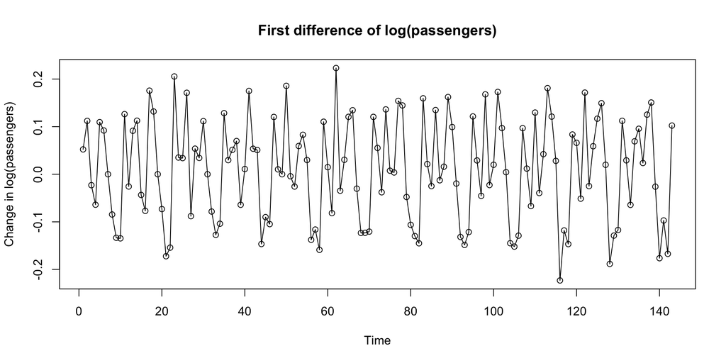

```r
plot(dy, type="o", main="First difference of log(passengers)", xlab="Time", ylab="Change in log(passengers)")
```

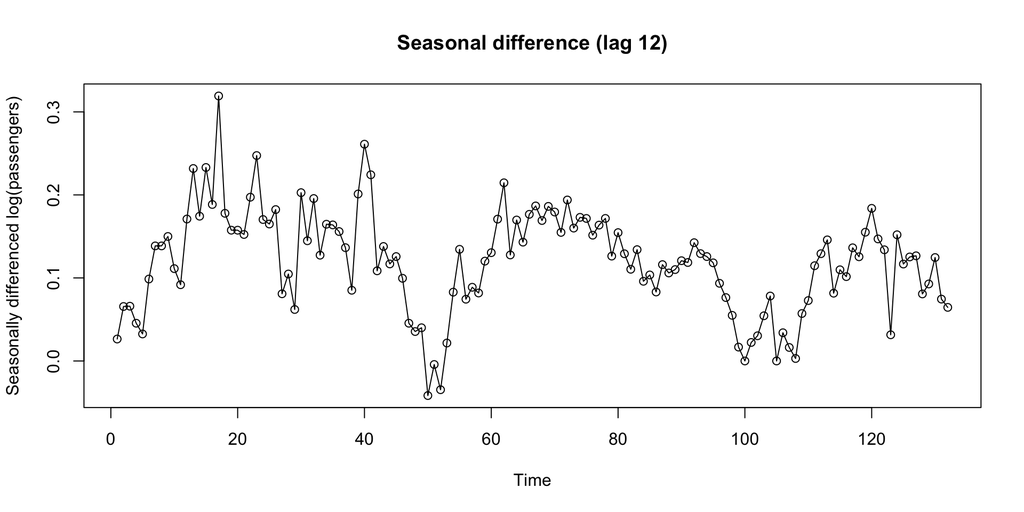

```r
de<-diff(y, lag=12) #differences of order 12
plot(de, type="o", main="Seasonal difference (lag 12)", xlab="Time", ylab="Seasonally differenced log(passengers)")
```

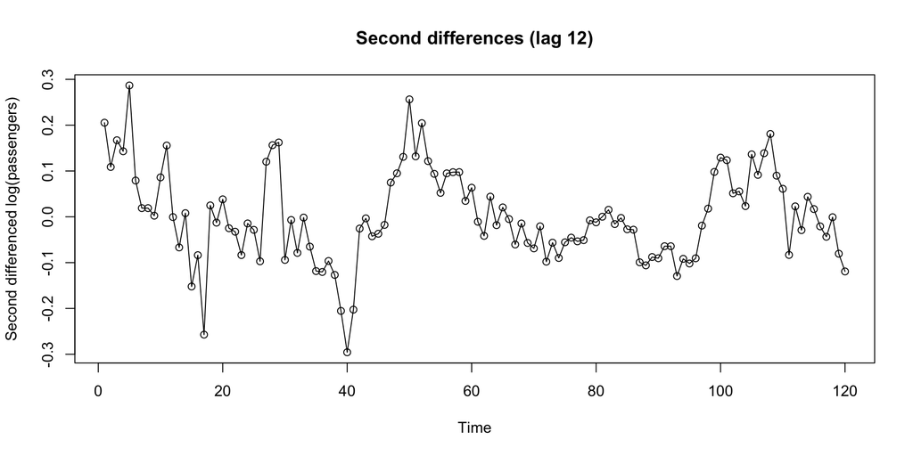

```r
de<-diff(y,12,2) #second differences of order 12
plot(de, type="o", main="Second differences (lag 12)", xlab="Time", ylab="Second differenced log(passengers)")
```

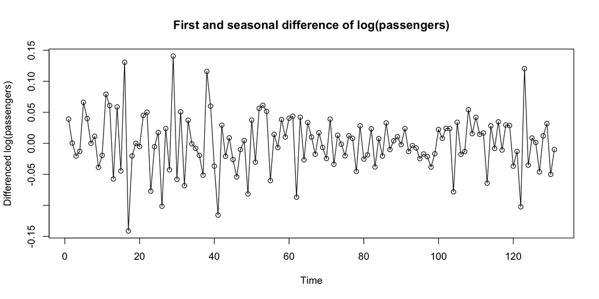

```r
y<-log(x)
dy12<-diff(y, lag=12)
#plot (dy12, xlab="time", ylab="passengers", type="o")
ddy12<-diff(dy12)
plot(ddy12, type="o", main="First and seasonal difference of log(passengers)", xlab="Time", ylab="Differenced log(passengers)")
```

1. **First order differentiation:** for each time point, diff(y) computes the difference between the value of the time point y_t and the previous y_{t-1}. We see that the linear trend is removed, there is no more an upward trend but rather the series fluctuates around zero. While the seasonality is still visible.
2. **Difference of order 12:** for each time point, diff(y, lag=12) computes the difference between the value of the time point y_t and the time point at 12 steps ago y_{t-12}. Since frequency = 12, it compares each month with the same month last year. This removes the yearly seasonal pattern.
3. **Second differences of order 12**: it applies the difference of order 12 twice
4. **Seasonal + first difference**: here we first removed seasonality with a **Difference of order 12**, and then we removed the trend with a **First order differentiation**. In this case we observe a time series that does not have a trend nor seasonality and it fluctuates around zero.

## 8. Decompositions

The practical says to take the time series xt and decompose it directly using a moving average only, as in the following example:

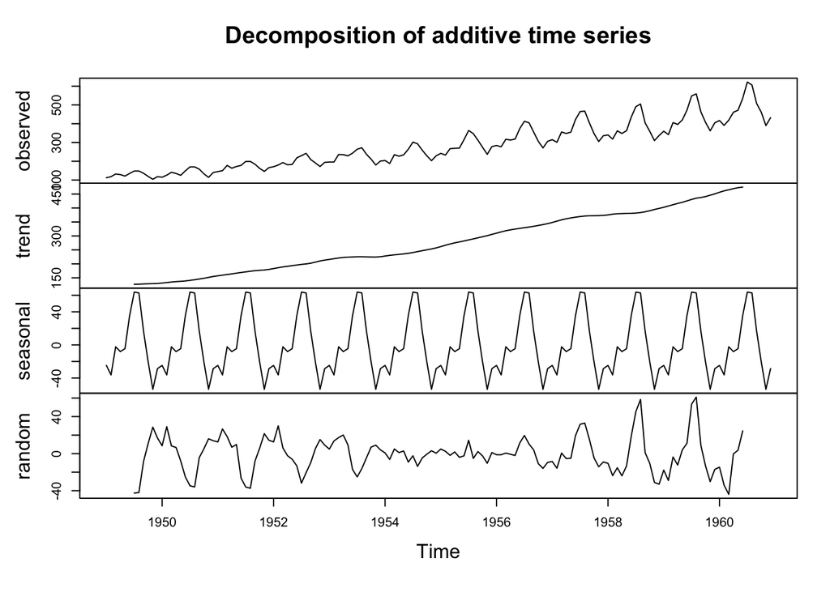

```r
plot (decompose(xt))
```

This is a very useful view that already summarizes all the components that earlier we obtained by manually subtracting points of the time series. The “observed” time series is the one that we originally plotted, i.e. the original time series. And it is composed of the other elements plotted below it: **Observed = Trend + Seasonal + Random**. In fact, if we add the parameter **type=“additive”** as in paragraph below, it will generate the same plot.

Now we can extract the components:

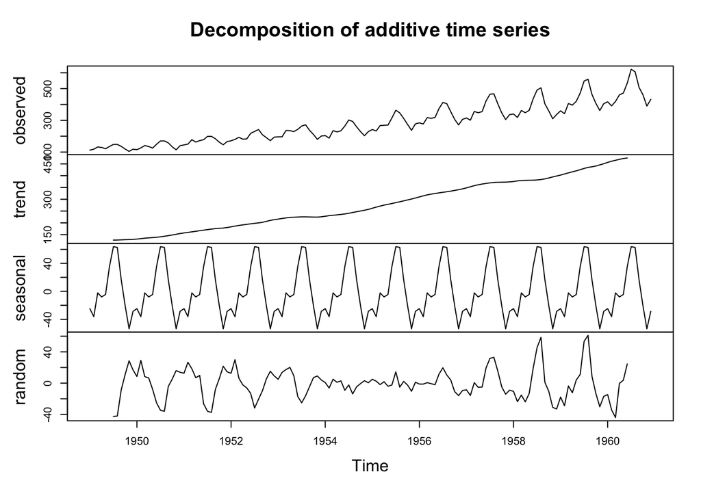

```r
dec<-decompose(xt, type="additive")
plot(dec)
```

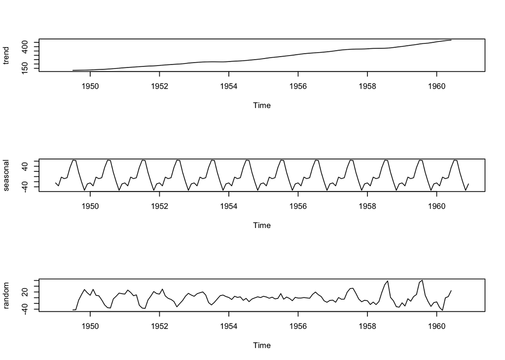

```r
trend<-dec$trend
seasonal<-dec$seasonal
random<-dec$random

layout(1:3)
plot(trend)
plot(seasonal)
plot(random)
```

The *decompose* function allows to easily visualize what are the trend, seasonal and random components of the observed time series - as well as to extract such components in very less steps.

# Practical 1B

### Simulation of Time Series in R

## 9. IID and Gaussian white noise

Simulation of **Independent and Identically Distributed (IID) Gaussian White Noise**. First, we define the sample size; we want a sample of 1000 data points. Then, we generate n random values from a standard normal distribution. This is called Gaussian White Noise, meaning: - Values are independent -> no correlation between points - Values are identically distributed -> all come from the same normal distribution

```r
# Number of data points
n <- 1000
# Standard white noise
z1 <- rnorm(n)
```

We can visualize the first 200 points as a line plot. As we can see, there’s clearly a lack of trend. This is typical for white noise. We can also visualize the distribution with a histogram. It plots the frequency distribution of all 1000 points. Parameter probability = TRUE scales the histogram to density, so it can be compared with a probability density function. Function dnorm(x) computes the standard normal density at points x. Function ‘lines’ drawa the density as a red line on the histogram. This allows us to compare the sample with the true normal distribution, showing that the sample correctly approximated the theoretical normal distribution.

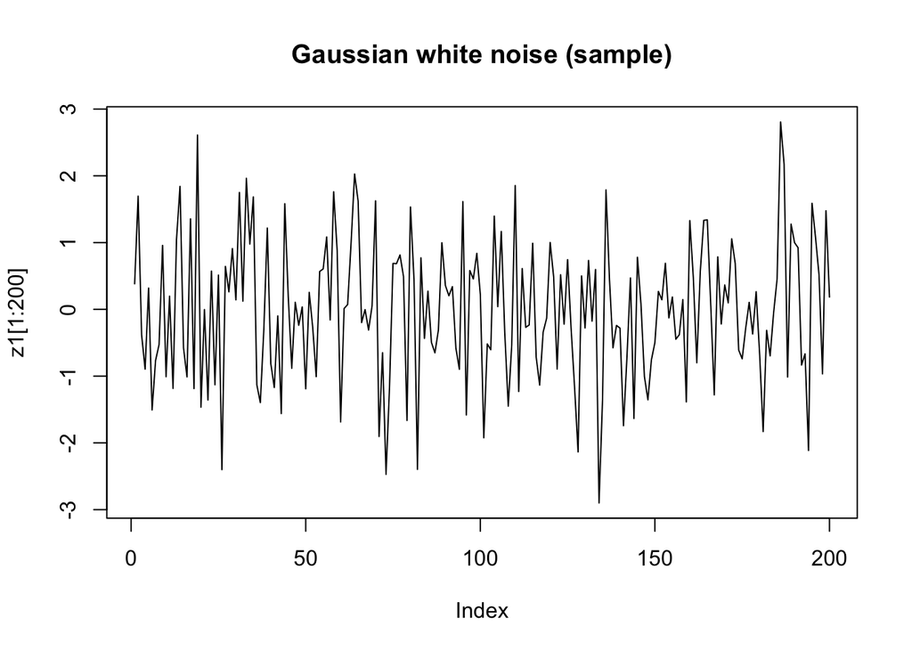

```r
plot(z1[1:200], type = "l", main = "Gaussian white noise (sample)")
```

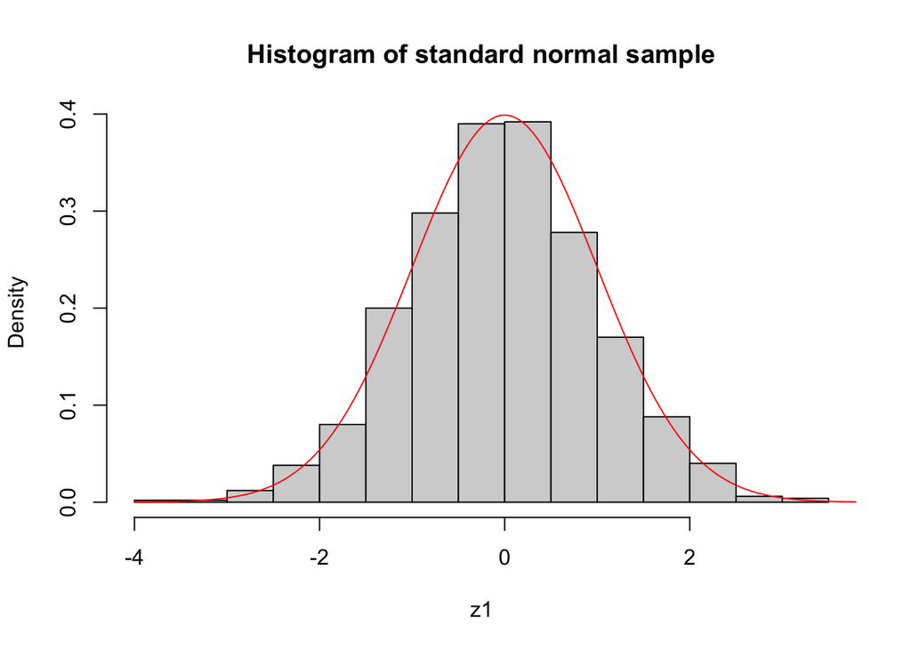

```r
hist(z1, probability = TRUE, main = "Histogram of standard normal sample")
x <- seq(-4, 4, length = 200)
lines(x, dnorm(x), col = "red")
```

### Sample definition variations

We can generate the sample without defining first n. Although the first approach is better, because it gives us more flexibility when programming.

```r
z1 <- rnorm(100)
z1
```

```
##   [1] -0.093343876 -0.465227940 -1.758213292  2.337906345 -0.008316829
##   [6] -0.456487194  0.542867052  0.159775421  0.768348232 -0.352714709
##  [11]  0.410711692 -1.815524897  0.184095322  0.168760598  1.445688037
##  [16]  0.666572921 -2.047486810  0.721447665  0.620797462 -0.621634578
##  [21]  0.273085222 -2.057221455 -0.294619079 -0.187831625  0.343120339
##  [26] -0.418835251 -0.487085433  0.494581208 -0.549802632  1.720425004
##  [31] -0.850050387 -0.332791510 -0.967808830  0.414566525  0.304731587
##  [36]  0.571977185  0.047099331  1.046867554 -0.109133555  0.247009297
##  [41] -1.429779921 -0.136819351 -0.006234843 -1.392391974  0.258835823
##  [46]  0.678360572  1.333484966 -0.057347241  0.896493334 -0.032249022
##  [51] -1.819618971 -0.903107661 -0.415992245 -1.357695319  0.307943084
##  [56]  0.357067955 -1.640721412 -1.208028646  1.695609078 -0.560517612
##  [61]  0.483655859  0.715643353  1.146533339  1.171526037 -2.165338515
##  [66]  0.499059239 -0.141113486 -1.473398226 -0.346416578 -1.167256261
##  [71] -0.878632763 -0.235578407 -0.316844178  0.103828220 -0.442466122
##  [76]  0.797107599 -0.054527521  0.338194074 -0.198214703 -0.178942808
##  [81] -0.394703992  0.891374396 -1.151211649  0.678536232  0.875355965
##  [86]  1.972313676 -0.946476947  0.565109015 -0.001863594 -1.177653135
##  [91]  0.073752478 -0.249000922  0.211757895 -0.351011751  0.908922718
##  [96] -0.927973039  2.165208708 -0.684173692 -0.609684964  0.208015475
```

### Gaussian White Noise with mean and standard deviation

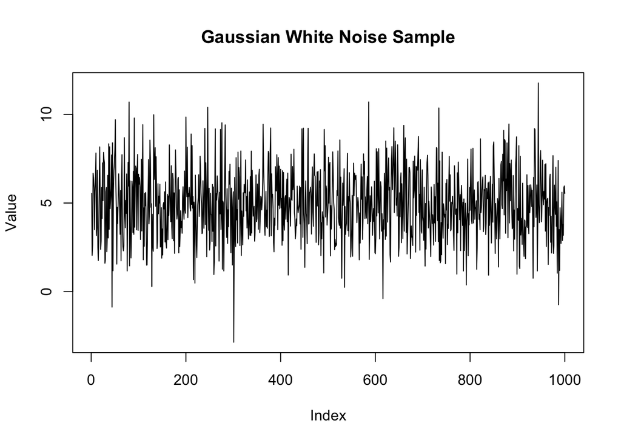

```r
# Gaussian white noise with mean 5 and std 2
mu <- 5
sigma <- 2
# Sample of a normal random variable with mean 5 and std 2
z2 <- rnorm(n, mean = mu, sd = sigma)
plot(z2, type = "l", xlab = "Index", ylab = "Value",
     main = "Gaussian White Noise Sample")
```

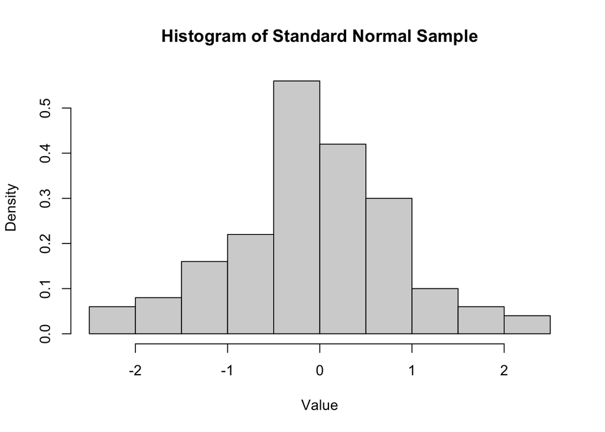

```r
hist(z1, freq = FALSE, main = "Histogram of Standard Normal Sample", xlab = "Value")
```

**What happens if we remove the parameter freq=F?** This parameter scales the histogram to a probability density. Removing the parameter plots fequencies instead of densities.

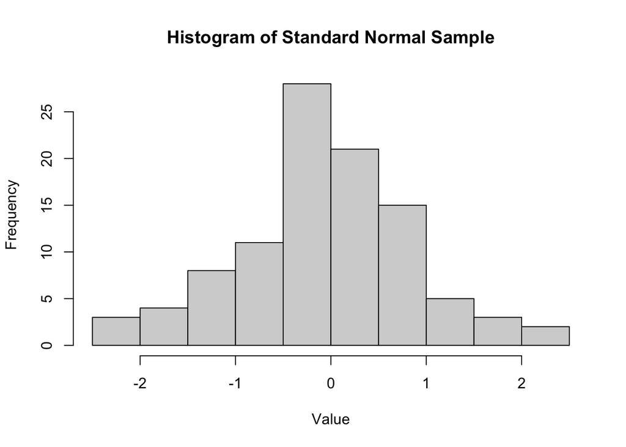

```r
hist(z1, main = "Histogram of Standard Normal Sample", xlab = "Value")
```